# VL08: Perzeptron, MLP (Aufbau)

IFM 5.6 Künstliche Intelligenz, 2017/18

Carsten Gips, FH Bielefeld

# Wiederholung

## Entscheidungsbäume

- Was ist der Unterschied zwischen CAL3 und ID3?

# Motivation

## Wie funktioniert Lernen im Gehirn?

[figure not shown]

Quelle: http://2.f.ix.de/scale/geometry/600/q75/imgs/18/1/4/1/5/1/4/4/KI-2ea6087a4309ab71.jpeg

## Themen für heute

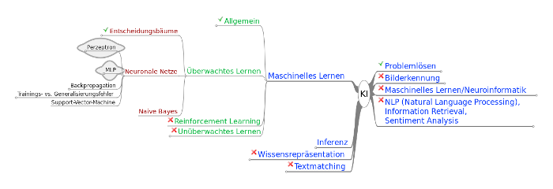

Am Ende der VL können/verstehen Sie:

- Aufbau und Funktionsweise von Nervenzellen
- Abstraktion einer Nervenzelle: Perzeptron
- Lernen mit dem Perzeptron
- Aufbau eines mehrlagigen Netzes (MLP)

# Perzeptron

## Erinnerung Skalarprodukt: Berechnung und Eigenschaften

### Vektoren

$\mathbf{v}$ ist ein Vektor mit $n$ Komponenten:

$$\vec{v} = \underline{v} = \mathbf{v} = \left(\begin{array}{c}
v_1 \\
v_2 \\
... \\
v_n \\
\end{array}\right)$$

Es sind verschiedene Schreibweisen gebräuchlich (s.o.), hier wird die Schreibweise “$\mathbf{v}$” bevorzugt.

### Skalarprodukt für Vektoren

$$\langle\mathbf{x},\mathbf{y}\rangle = \mathbf{x} \cdot \mathbf{y} = \mathbf{x}^T\mathbf{y} = x_1 y_1 + x_2 y_2 + ... + x_n y_n = \sum_j x_j y_j = |\mathbf{x}| |\mathbf{y}| \cos{\phi}$$

- Betrag: $|\mathbf{a}| = \sqrt{\langle\mathbf{a},\mathbf{a}\rangle} = \sqrt{\mathbf{a}^2}$
- Symmetrie: $\langle\mathbf{x},\mathbf{y}\rangle = \langle\mathbf{y},\mathbf{x}\rangle$
- Linearität:
  - $\langle\mathbf{x}, \lambda \mathbf{y}\rangle = \lambda \langle\mathbf{x},\mathbf{y}\rangle$
  - $\langle\mathbf{x}+\mathbf{y}, \mathbf{z}\rangle = \langle\mathbf{x},\mathbf{z}\rangle + \langle\mathbf{y},\mathbf{z}\rangle$
- $\mathbf{x}$ und $\mathbf{y}$ senkrecht: $\langle\mathbf{x},\mathbf{y}\rangle = 0$

Tafel: Vektoren, Winkel

## Biologisches Vorbild Nervenzelle

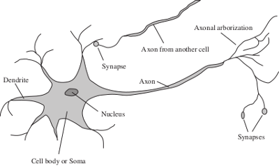

Quelle: [AIMA 3rd ed.](http://aima.cs.berkeley.edu)

- Neuron besteht aus Dendriten, der eigentlichen Zelle (Soma) und einem Axon
- Signale werden elektro-chemisch verarbeitet:
  - Die Dendriten bilden Eingänge für die Signale
  - Weiterleitung beeinflusst die Signale durch Eigenschaften der Dendriten (Form => Widerstand, Laufzeit)
  - Im Soma summiert sich das elektrische Potential
  - Wenn eine Schwelle überschritten wird, “feuert” das Axon, d.h. sendet elektrische Impulse aus
  - In den Synapsen erfolgt die Signalübertragung auf chemischem Wege durch Botenstoffe auf die Dendriten der verbundenen Neurone
- Signale sind Impulse unterschiedlicher Frequenz, Dauer und Spannung
- Lernen:
  - Veränderung der Eigenschaften der Nervenzelle selbst
  - Veränderung der Vernetzung der Nervenzellen untereinander

## Perzeptron als Modell der Nervenzelle

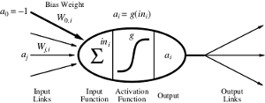

Quelle: [AIMA 3rd ed.](http://aima.cs.berkeley.edu)

$$a_i = \left\{
\begin{array}{lll}
1 & \text{ falls } & a_1 w_{1,i} + a_2 w_{2,i} + ... + a_n w_{n,i} \ge w_{0,i}\\
0 & \text{ falls } & a_1 w_{1,i} + a_2 w_{2,i} + ... + a_n w_{n,i} < w_{0,i}
\end{array}
\right.$$

$$a_i = \operatorname{g} \left(in_i \right) = \operatorname{g} \left(\sum_{j=1}^n w_{j,i} a_j - w_{0,i} \right) = \operatorname{g} \left(\sum_j w_{j,i} a_j \right) = \operatorname{g} \left(\langle\mathbf{w}_i,\mathbf{a}\rangle\right)$$

## Achtung Schreibweise: AIMA vs. “Rest der Welt”

Im AIMA wird eine eher unübliche Schreibweise genutzt. Nachfolgend die in der Literatur gebräuchliche:

- Übliche Bedeutung von $w_{ji}$: Gewicht gehört zu Neuron $j$ (und führt zum Input $i$)
- Aktivierung Neuron $j$: $a_j = \sum_i w_{ji} x_i = \langle\mathbf{w}_j,\mathbf{x}\rangle$ (wobei $x_i$ der Input von Neuron $j$ ist)
  - mit Bias: Gewicht $w_{j0}$ mit Input $x_0 \stackrel{!}{=} +1$
- Ausgabe von Neuron $j$: $z_j = \operatorname{g}(a_j)$

*Anmerkung*: Der Gewichtsvektor $\mathbf{w}$, der auch $w_0$ enthält, wird “erweiterter Gewichtsvektor” genannt.

## Bemerkung zu alternativer Schreibweise

Häufig ist auch folgende (eher historische) Schreibweise für die Berechnung eines Perzeptrons anzutreffen:

$$y(\mathbf{x}) = \operatorname{g} \left(\sum_{i=1}^n w_i x_i - \theta \right)$$

Erinnerung (gebräuchliche Schreibweise):

$$z_j = \left\{
\begin{array}{lll}
1 & \text{ falls } & x_0 w_{j0} + x_1 w_{j1} + x_2 w_{j2} + ... + x_n w_{jn} \ge 0\\
0 & \text{ falls } & x_0 w_{j0} + x_1 w_{j1} + x_2 w_{j2} + ... + x_n w_{jn} < 0
\end{array}
\right.$$

mit $x_0 \stackrel{!}{=} +1$.

Wenn man in den beiden Ungleichungen das Bias-Gewicht $w_{j0}$ (das Gewicht mit der konstanten(!) Eingabe $+1$) auf die rechte Seite bringt, d.h. mit $1, \text{ falls } ... \ge -w_{j0}$ bzw. $0, \text{ falls } ... < -w_{j0}$, sieht man den Effekt von $w_{j0}$ sofort: Die Summe muss größer oder kleiner als $-w_{j0}$ sein, damit es zu einem bestimmten Output des Neurons kommt, d.h. $-w_{j0}$ bildet die Schwelle, an der die Ausgabe des Neurons kippt. Diese Schwelle hat man früher gern mit $\theta$ bezeichnet, d.h. $\theta = -w_{j0}$.

So sieht man zwar besser, dass man eine Schwelle in der Gleichung hat. Leider verhindert das andererseits, dass man die Berechnungsformel direkt über ein Skalarprodukt ausdrücken kann … Durch eine einfache Umbenennung von $-\theta$ in $w_0$ sind wir aber direkt bei der heute gebräuchlichen Form :-)

1. Setze $w_0 = -\theta$ => $y(\mathbf{x}) = \operatorname{g} \left(\sum_{i=1}^n w_i x_i + w_0 \right)$
2. Setze $x_0 = +1$ => $y(\mathbf{x}) = \operatorname{g} \left(\sum_i w_i x_i \right) = \operatorname{g} \left(\langle\mathbf{w},\mathbf{x}\rangle\right)$

*Anmerkung*: Der Gewichtsvektor $\mathbf{w}$, der das $w_0$ **nicht** enthält, wird auch “einfacher Gewichtsvektor” genannt.

*Anmerkung*: Ob der einfache oder erweiterte Gewichtsvektor gemeint ist, ergibt sich in der Regel aus dem Kontext (oder es wird explizit erwähnt): Wenn für ein Neuron $\operatorname{g} \left(\langle\mathbf{w},\mathbf{x}\rangle\right)$ geschrieben wird, ist der erweiterte Gewichtsvektor gemeint. Wenn dagegen $\operatorname{g} \left(\langle\mathbf{w},\mathbf{x}\rangle - \theta\right)$ verwendet wird, meint man die Variante mit dem einfachen Gewichtsvektor.

## Aktivierungsfunktionen

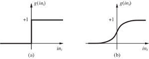

Quelle: [AIMA 3rd ed.](http://aima.cs.berkeley.edu)

1. Sprungfunktion $g(x) = \operatorname{sign}(x) = \left\{ \begin{array}{ll} 0 & \text{falls } x<0\\ 1 & \text{sonst} \end{array} \right.$
2. Sigmoide Funktion $g(x) = 1/(1+e^{-x})$

*Anmerkung*: Sprungfunktion $\operatorname{sign}$: $\{0, 1\}$, $\operatorname{sgn}$: $\{-1, +1\}$

*Hinweis*: Die Aktivierungsfunktion wird auch häufig “Transferfunktion” genannt.

## Beispiele: Wie sieht w aus?

| $x_1$ | $x_2$ | $k$ |
| --- | --- | --- |
| 0 | 0 | 0 |
| 0 | 1 | 0 |
| 1 | 0 | 0 |
| 1 | 1 | 1 |

| $x_1$ | $k$ |
| --- | --- |
| 0 | 1 |
| 1 | 0 |

|  | $w_1$ | $w_2$ | $w_0$ |
| --- | --- | --- | --- |
| AND | 1 | 1 | -1.5 |
| NOT | -1 |  | 0.5 |

## Interpretation

*Anmerkung*: Die folgenden Bemerkungen beziehen sich auf den *erweiterten Gewichtsvektor*!

- Perzeptron: $y(\mathbf{x}) = \operatorname{sign} \left(\langle\mathbf{w},\mathbf{x}\rangle\right)$
- Entscheidungsgrenze: $\langle\mathbf{w},\mathbf{x}\rangle = 0$ (mit erweitertem Gewichtsvektor)

Zweidimensional:
$$w_1 x_1 + w_2 x_2 + w_0 = 0$$

Umformen:
$$x_2 = -\frac{w_1}{w_2} x_1 - \frac{w_0}{w_2}$$

Interpretation: **Geradengleichung** $y = n x + a$ mit $n = \Delta y/\Delta x$ (Steigung) und Nulldurchgang bei $a$

Tafel: Beispiel Trennebene AND

## Zusammenhang mit Skalarprodukt

*Anmerkung*: Die folgenden Bemerkungen beziehen sich auf den *einfachen Gewichtsvektor*!

- Entscheidungsgrenze: $\langle\mathbf{w},\mathbf{x}\rangle - \theta = 0$ (alternative Schreibweise mit einfachem Gewichtsvektor)
- Hessesche Normalform einer Ebene: $H = \{x \in \mathbb{R}^{n} \mid \langle\mathbf{v},\mathbf{x}\rangle = d \}$
  - $\mathbf{v}$ ist ein *normierter* Normalenvektor der Hyperebene (steht senkrecht)
  - $d$ ist der Abstand der Ebene zum Ursprung

=> $\mathbf{w}$ in obiger Gleichung normieren

=> Perzeptron entspricht Trennebene:
$$\left\langle\frac{\mathbf{w}}{|\mathbf{w}|},\mathbf{x}\right\rangle = \frac{\theta}{|\mathbf{w}|}$$

- Gewichtsvektor $\mathbf{w}$ steht senkrecht zur Ebene ($\frac{\mathbf{w}}{|\mathbf{w}|}$ ist der normierte Normalenvektor der Trennebene)
- Abstand der Ebene zum Ursprung ist $\frac{\theta}{|\mathbf{w}|}$ (bzw. $\frac{-w_0}{|\mathbf{w}|}$)
- $\left\langle\frac{\mathbf{w}}{|\mathbf{w}|},\mathbf{x}\right\rangle$ ist die Länge der orthogonalen Projektion von $\mathbf{x}$ auf den Einheitsvektor $\frac{\mathbf{w}}{|\mathbf{w}|}$
  - Alle Punkte $\mathbf{x}$, bei denen die Länge der orthogonalen Projektion größer/gleich als der Abstand der Trennebene vom Ursprung ist, werden mit $+1$ klassifiziert.
  - Alle Punkte $\mathbf{x}$, bei denen diese Projektion kleiner ist als der Abstand der Trennebene zum Ursprung, werden mit $0$ (bzw. $-1$ bei der Verwendung von $\operatorname{sgn}$) klassifiziert.

Tafel: Skizze Trennebene, Gewichtsvektor, Projektion

## Perzeptron-Lernregel

- Aktuelles Beispiel: $\left(\mathbf{x}^{(\alpha)}, y_T^{(\alpha)}\right)$
- Forderung: $y_T^{(\alpha)} = y(\mathbf{x}^{(\alpha)}, \mathbf{w})$
- Fallunterscheidung:
  1. $y_T^{(\alpha)} = y(\mathbf{x}^{(\alpha)}, \mathbf{w})$ => keine Gewichtsänderung
  2. $y_T^{(\alpha)} = 0$ und $y(\mathbf{x}^{(\alpha)}, \mathbf{w}) = 1$ => $\langle\mathbf{w},\mathbf{x}^{(\alpha)}\rangle$ ist zu groß
  3. $y_T^{(\alpha)} = 1$ und $y(\mathbf{x}^{(\alpha)}, \mathbf{w}) = 0$ => $\langle\mathbf{w},\mathbf{x}^{(\alpha)}\rangle$ ist zu klein
- **Lernregel**: $w_i \; \gets \; w_i + \eta \left(y_T^{(\alpha)} - y(\mathbf{x}^{(\alpha)}, \mathbf{w})\right) \cdot x^{(\alpha)}_i$
  - Lernschrittweite $\eta$: kleine, positive Zahl (beispielsweise 0.1 oder 0.05)

Tafel: Beispiel

# Feedforward MLP

## Perzeptron ist limitiert

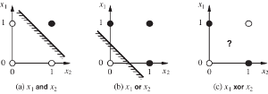

Quelle: [AIMA 3rd ed.](http://aima.cs.berkeley.edu)

$$y = \operatorname{sign} \left(\langle\mathbf{w},\mathbf{x}\rangle\right)$$

=> Nur für linear separable Probleme!

## Lösung des XOR-Problems

Mögliche Lösungen:

- Inputs transformieren => aus $x_1$ und $x_2$ noch ein (geeignetes!) $x_3$ generieren
- Mehrschichtiges Netz verwenden: Multilayer Perzeptron (MLP)

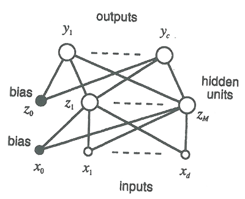

Quelle: Bishop: “Neural Networks for Pattern Recognition”, Oxford University Press

Hinweis Feedforward-Phase

## Mehrlagiges Perzeptron: Entscheidungsgrenzen

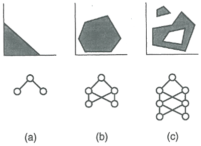

Quelle: Bishop: “Neural Networks for Pattern Recognition”, Oxford University Press

Aktivierungsfunktion: Threshold-Funktion, z.B. $g(x) = \operatorname{sign}(x)$

*Hinweis*: In der Abbildung ist die erste “Schicht” keine echte Schicht mit Neuronen, sondern stellt lediglich die Inputwerte dar.

## Mehrlagiges Perzeptron: Funktionsapproximation

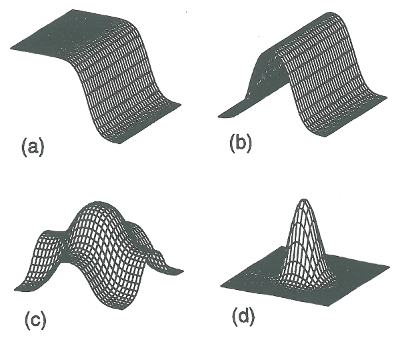

Quelle: Bishop: “Neural Networks for Pattern Recognition”, Oxford University Press

Aktivierungsfunktion: Soft Threshold-Funktion, z.B. $g(x) = \frac{1}{(1+\exp(-x))}$

## MLP: Wie trainieren? Fehler über den Gewichten!

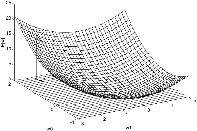

Quelle: [AIMA 3rd ed.](http://aima.cs.berkeley.edu)

- Fehler: Abweichung IST- und SOLL-Output (berechneter Output und Vorgabe durch den Trainer)
- Trainieren bedeutet Fehler zu reduzieren => Parameter anpassen
- Die einzigen (änderbaren) Parameter im Modell sind die Gewichte der Neurone

=> Fehler als Funktion der Gewichte betrachten

## Quadratische Fehlerfunktion und Gradientenabstieg

- **Ziel**: Verändere Gewichte so, dass Fehler minimiert wird => Gradientenabstieg
- **Fehlerfunktion**:
  $$E(\mathbf{w}) = \frac{1}{2} \sum_d (y^{(d)} - t^{(d)})^2$$
  - $t^{(d)}$ … vorgegebene Klasse aus dem Trainingsbeispiel Nr. $d$
  - $y^{(d)}$ … Ausgabe des Neurons zu Trainingsbeispiel Nr. $d$, d.h.
    $$y^{(d)} = y(\mathbf{x}^{(d)}) = g(\langle\mathbf{w},\mathbf{x}^{(d)}\rangle)$$
  - Fehler entsteht durch die Abweichung vom IST- und SOLL-Output (berechneter Output und der Vorgabe durch den Trainer) pro Trainingsbeispiel
  - Aufsummieren aller Einzelfehler für den Trainingsdatensatz
  - Quadratischer Fehler: Falls die Differenz $y^{(d)} - t^{(d)}$ negativ ist, haben wir ja immer noch einen Fehlerbeitrag. Die Summe (d.h. der Gesamtfehler) soll sich aber durch solche negativen Beiträge nicht verkleinern!

    Eine mögliche Lösung wäre das Aufsummieren der Beträge der Differenzen, aber das führt später zu kleineren Schwierigkeiten (Stichwort Differenzierbarkeit, vgl. nächste VL). Das Quadrat über der Differenz behebt beide Probleme …

*Anmerkung*: Zunächst Betrachtung nur eines Neurons

- Sonst müssten wir zusätzlich noch über alle Neurone in der Ausgabeschicht summieren, da ja jedes am Gesamtfehler beteiligt ist.

## Gradientenabstieg: Ändere die Gewichte (Delta-Regel)

$$\mathbf{w} \gets \mathbf{w} + \Delta\mathbf{w}$$
mit
$$\Delta\mathbf{w} = -\eta\nabla E(\mathbf{w})$$

=> Gehe in Richtung des negativen Gradienten

($\eta$: Laufschrittweite, kleine positive Zahl, z.B. $0.05$)

$$\nabla E(\mathbf{w}) = \left( \frac{\partial E}{\partial w_{0}}, \frac{\partial E}{\partial w_{1}}, \ldots, \frac{\partial E}{\partial w_{n}} \right)^T$$

Darum kümmern wir uns nächste VL ...

# Zusammenfassung

## tl;dr

- Perzeptron als Modell der menschlichen Nervenzelle
  - Eingänge werden gewichtet und aufsummiert
  - Überschreiten einer Schwelle: Neuron “feuert” (Ausgabe 1, sonst 0)
- Berechnungsvorschrift, Lernregel und Interpretation für Perzeptron
  - Lernen als Veränderung der Gewichte
- Begriff des Mehrlagen-Perzeptrons (MLP)
- Feedforward-Phase des MLP
- Idee: Fehler eines Neurons: Gradientenabstieg, Delta-Regel

**Nächste Woche**: MLP (Gradientenabstieg, Delta-Regel, Backpropagation)

## Literatur zum Weiterlesen

- Russell, Norvig: “Artificial Intelligence: A Modern Approach, 3rd ed.”
  - Perzeptron: Abschnitte 18.6.3, 18.7.1, 18.7.2
- Mitchell: “Machine Learning”, McGraw-Hill
  - Perzeptron: Abschnitte 4.1 … 4.4
- Bishop: “Neural Networks for Pattern Recognition”, Oxford University Press
  - Perzeptron: Abschnitte 3.1, 3.2, 3.5
  - MLP: Kapitel 4

## Lernziele – Nach dieser Vorlesung sollten Sie …

### Verstehen (K2)

- Perzeptron als Modell der Nervenzelle
- Begriff des Mehrlagen-Perzeptrons (MLP)

### Anwenden (K3)

- Berechnungsvorschrift, Lernregel und Interpretation für Perzeptron
- Feedforward-Phase des MLP

## Diese Fragen sollten Sie beantworten können …

### Arbeitsweise Perzeptron

- Lernen Sie mit einem Perzeptron die logischen Funktionen `AND`, `OR`, `XOR`.
- Unter welchen Bedingungen kann ein Perzeptron zwei Klassen fehlerfrei unterscheiden?
- Lösen Sie Aufgabe 18.24 aus dem Buch (RN03/AIMA) auf Seite 766 (Anwendung Perzeptron-Lernregel).